# R Notebook

```r
library(DESeq2)
library(tidyverse)
library(ggplot2)
library(reshape2)
```

Load metadata

```r
meta <- read.csv("data/metadata/meta_RNAseq.csv", row.names = 1) %>%
  # Batch as character
  mutate(Batch = as.character(Batch)) %>%
  dplyr::filter(!SampleID==c("GMCC1S1", "GMCC1S6", "GMCC2S3", "GMCC4S7")) %>%
  dplyr::filter(!SampleName=="4342XH") %>%
  mutate(coculture = ifelse(grepl("control", SampleName), "control", "microbiome")) %>%
  # Replace 0s in urbanism with control
  mutate(urbanism = replace(urbanism, is.na(urbanism), "control")) %>%
  mutate(country = replace(country, is.na(country), "control")) %>%
  # Add one more column, urbanism2, which separates USA from non-USA urban
  mutate(urbanism2=ifelse(country=="USA", "USA_urban", urbanism)) %>%
  mutate(urbanism2 = replace(urbanism2, is.na(urbanism2), "control")) %>%
  mutate(rnames=SampleID) %>%
  column_to_rownames("rnames")
meta <- meta[order(row.names(meta)), ]
```

Import raw read counts

```r
raw_read_cts_filt <- read.csv("results/docs/raw_read_cts_filt.csv", row.names=1)
raw_read_cts_filt <- raw_read_cts_filt[, colnames(raw_read_cts_filt) %in% meta$SampleID]
raw_read_cts_filt <- raw_read_cts_filt[, order(colnames(raw_read_cts_filt))]
```

Run DESeq model

```r
dds <- DESeq(
    DESeqDataSetFromMatrix(
      countData = raw_read_cts_filt,
      colData = meta,
      design= ~Batch + urbanism))
```

Results

```r
res_uc <- results(dds, contrast = c("urbanism", "urban", "control")) %>%
  as.data.frame() %>%
  rownames_to_column("ensembl_gene_id")

res_rc <- results(dds, contrast = c("urbanism", "rural", "control")) %>%
  as.data.frame() %>%
  rownames_to_column("ensembl_gene_id")

res_ur <- results(dds, contrast = c("urbanism", "urban", "rural")) %>%
  as.data.frame() %>%
  rownames_to_column("ensembl_gene_id")
```

Filter for significance

```r
sig_uc <- res_uc %>%
  dplyr::filter(padj<0.1) %>%
  dplyr::filter(log2FoldChange > 0.1 | log2FoldChange < -0.1) %>%
  mutate(model="sig_uc")
sig_rc <- res_rc %>%
  dplyr::filter(padj<0.1) %>%
  dplyr::filter(log2FoldChange > 0.1 | log2FoldChange < -0.1) %>%
  mutate(model="sig_rc")
sig_ur <- res_ur %>%
  dplyr::filter(padj<0.1)
```

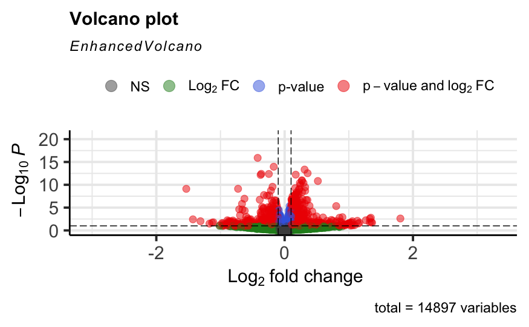

```r
library(EnhancedVolcano)
EnhancedVolcano(res_uc,
    lab = NA,
    x = 'log2FoldChange',
    y = 'pvalue',
    pCutoff = 0.1,
    FCcutoff = 0.1,
    pointSize = 3.0,
    labSize = 6.0)
```

L2FC scatterplot

```r
# Shared
sig_shared <- intersect(sig_uc$ensembl_gene_id, sig_rc$ensembl_gene_id)
# Unique
sig_uc_only <- sig_uc %>%
  dplyr::filter(!ensembl_gene_id %in% sig_shared)
sig_rc_only <- sig_rc %>%
  dplyr::filter(!ensembl_gene_id %in% sig_shared)

res_uc_lab <- res_uc %>%
  dplyr::select(ensembl_gene_id, log2FoldChange, padj, pvalue) %>%
  mutate(neg_log10_padj = -log10(padj)) %>%
  rename_with(~paste0(., "_uc"), -1)
res_rc_lab <- res_rc %>%
  dplyr::select(ensembl_gene_id, log2FoldChange, padj, pvalue) %>%
  mutate(neg_log10_padj = -log10(padj)) %>%
  rename_with(~paste0(., "_rc"), -1)

res_uc_rc <- merge(
  res_uc_lab[,c("ensembl_gene_id", "log2FoldChange_uc", "padj_uc", "neg_log10_padj_uc")],
  res_rc_lab[,c("ensembl_gene_id", "log2FoldChange_rc", "padj_rc", "neg_log10_padj_rc")],
  by="ensembl_gene_id") %>%
  mutate(color_group = case_when(ensembl_gene_id %in% sig_shared ~ "Shared",
                                 ensembl_gene_id %in% sig_rc_only$ensembl_gene_id ~ "Rural only",
                                 ensembl_gene_id %in% sig_uc_only$ensembl_gene_id ~ "Urban only",
                                 !ensembl_gene_id %in% sig_shared ~ "z_Non-sig")) %>%
  mutate(sig = case_when(color_group != "z_Non-sig" ~ "Sig",
                         color_group == "z_Non-sig" ~ "z_Non-sig")) %>%
  mutate(abs_l2fc_uc = abs(log2FoldChange_uc)) %>%
  mutate(abs_l2fc_rc = abs(log2FoldChange_rc)) %>%
  arrange(desc(color_group))
```

Find most extreme genes belonging to uc or rc

```r
# Add an additional condition to exclude rows where padj or l2FC values are NA
res_uc_rc_rank <- res_uc_rc[complete.cases(res_uc_rc[, c("padj_uc", "padj_rc", "neg_log10_padj_uc", "neg_log10_padj_rc", "log2FoldChange_uc", "log2FoldChange_rc")]), ]
# Add a condition to exclude rows where padj < 0.01 in both uc and rc models
res_uc_rc_rank <- res_uc_rc_rank[(res_uc_rc_rank$padj_uc < 0.01 | res_uc_rc_rank$padj_rc < 0.01), ]

res_uc_rc_rank$neg_log10_padj_diff <- abs(res_uc_rc_rank$neg_log10_padj_uc - res_uc_rc_rank$neg_log10_padj_rc)
res_uc_rc_rank$l2FC_diff <- abs(res_uc_rc_rank$log2FoldChange_uc - res_uc_rc_rank$log2FoldChange_rc)

res_uc_rc_rank$neg_log10_padj_rank <- rank(-res_uc_rc_rank$neg_log10_padj_diff)
res_uc_rc_rank$l2FC_rank <- rank(-res_uc_rc_rank$l2FC_diff)

res_uc_rc_rank$rank_sum <- rowSums(res_uc_rc_rank[, c("neg_log10_padj_rank", "l2FC_rank")])

top_genes <- res_uc_rc_rank[order(res_uc_rc_rank$rank_sum), ][1:100, ] %>%
  mutate(most_extreme = "Most_Extreme: Urban v Control vs. Rural v Control")
```

```r
res_uc_rc_v2 <- res_uc_rc %>%
  left_join(top_genes[,c("ensembl_gene_id", "most_extreme")], by="ensembl_gene_id") %>%
  mutate(sig_extreme = case_when(most_extreme == "Most_Extreme: Urban v Control vs. Rural v Control" & sig=="Sig" ~ "Extreme",
                                 T ~ sig)) %>%
  arrange(desc(sig_extreme))
```

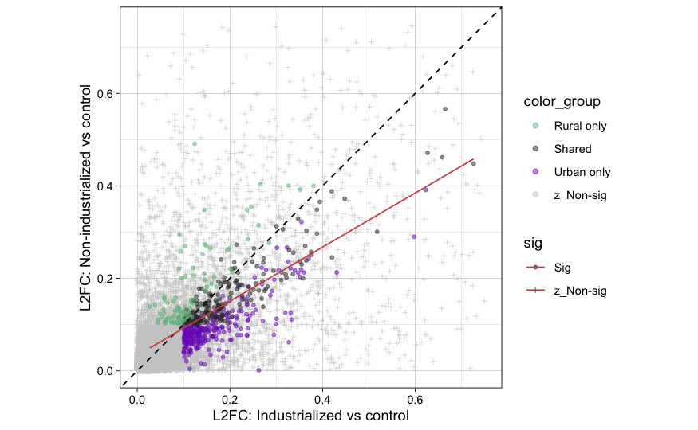

```r
ggplot(res_uc_rc, aes(x=abs_l2fc_uc, y=abs_l2fc_rc, color=color_group, fill=sig, shape=sig, size=sig)) +
  geom_point(alpha=0.5) +
  scale_shape_manual(values=c(19,3)) +
  scale_color_manual(values=c("#6FBD8B", "grey20", "#7B2BC1", "grey80")) +
  scale_size_manual(values=c(1,1)) +
  geom_abline(linetype="dashed")+
  geom_smooth(data = subset(res_uc_rc_v2, sig == "Sig"), method = "lm", se = FALSE, size=0.5, color="indianred3") +
  xlab("L2FC: Industrialized vs control") +
  ylab("L2FC: Non-industrialized vs control") +
  #xlim(values=c(-0.75,0.75)) +
  #ylim(values=c(-0.75,0.75)) +
  xlim(values=c(0, 0.75)) +
  ylim(values=c(0, 0.75)) +
  theme_linedraw() +
  coord_fixed() #+
```

```r
  #theme(legend.position="none")
```

```r
most_sig <- rbind(res_uc, res_rc) %>%
  arrange(padj) %>%
  slice_head(n = 100) %>%
  distinct(ensembl_gene_id) %>%
  pull()

res_uc_lab2 <- res_uc %>%
  dplyr::select(ensembl_gene_id, log2FoldChange, padj) %>%
  mutate(contrast = "uc")
res_rc_lab2 <- res_rc %>%
  dplyr::select(ensembl_gene_id, log2FoldChange, padj) %>%
  mutate(contrast = "rc")

res_uc_rc_lab2 <-
  rbind(res_uc_lab2, res_rc_lab2) %>%
  left_join(res_uc_rc[,c("ensembl_gene_id", "sig", "color_group")], by="ensembl_gene_id") %>%
  dplyr::filter(sig=="Sig") %>%
  mutate(ind_sig = case_when(padj<0.005 ~ "Sig",
                             padj>0.005 ~ "NS")) %>%
  mutate(neg_log10_padj = -log10(padj)) %>%
  dplyr::filter(ensembl_gene_id %in% most_sig)

sorted_df <- res_uc_rc_lab2 %>%
  group_by(ensembl_gene_id, log2FoldChange) %>%
  mutate(avg_l2FC = log2FoldChange) %>%
  arrange(avg_l2FC) %>%
  dplyr::select(ensembl_gene_id)
res_uc_rc_lab2$ensembl_gene_id <- factor(res_uc_rc_lab2$ensembl_gene_id, levels=unique(sorted_df$ensembl_gene_id))
```

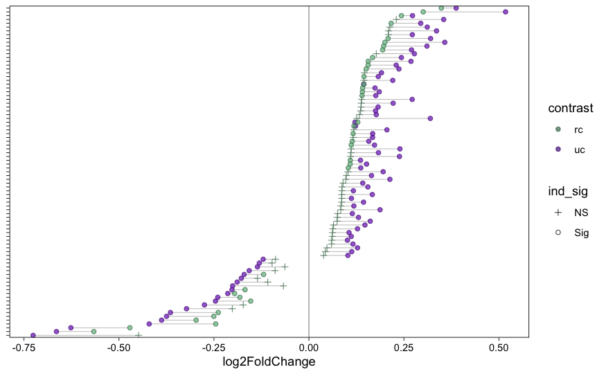

```r
ggplot(res_uc_rc_lab2, aes(x=log2FoldChange, y=ensembl_gene_id, fill=contrast, color=contrast, shape=ind_sig)) +
  geom_path(aes(group=ensembl_gene_id), color="grey", size=0.25) +
  geom_point(alpha=0.7) +
  scale_shape_manual(values=c(3,21)) +
  scale_color_manual(values=c("#457657", "#551D87")) +
  scale_fill_manual(values=c("#6FBD8B", "#7B2BC1")) +
  theme_linedraw() +
  theme(panel.grid.major.y = element_blank(),
        panel.grid.minor.y = element_blank(),
        panel.grid.major.x = element_blank(),
        panel.grid.minor.x = element_blank(),
        #legend.position="none",
        axis.title.y = element_blank(),
        axis.text.y = element_blank()) +
  geom_vline(xintercept=0, color="grey")
ggsave("results/figs/RNAseq-urbanism/gene_l2fC_dotplot.png", width=3, height=7)
```

```r
library(lattice)
qqunif.plot<-function(pvalues,
    should.thin=T, thin.obs.places=2, thin.exp.places=2,
    xlab=expression(paste("Expected (",-log[10], " p-value)")),
    ylab=expression(paste("Observed (",-log[10], " p-value)")),
    draw.conf=TRUE, conf.points=1000, conf.col="lightgray", conf.alpha=.05,
    already.transformed=FALSE, pch=20,
    #aspect="iso",
    aspect=0.5,
    prepanel=prepanel.qqunif,
    par.settings=list(superpose.symbol=list(pch=pch)), ...) {


    #error checking
    if (length(pvalues)==0) stop("pvalue vector is empty, can't draw plot")
    if(!(class(pvalues)=="numeric" ||
        (class(pvalues)=="list" && all(sapply(pvalues, class)=="numeric"))))
        stop("pvalue vector is not numeric, can't draw plot")
    if (any(is.na(unlist(pvalues)))) stop("pvalue vector contains NA values, can't draw plot")
    if (already.transformed==FALSE) {
        if (any(unlist(pvalues)==0)) stop("pvalue vector contains zeros, can't draw plot")
    } else {
        if (any(unlist(pvalues)<0)) stop("-log10 pvalue vector contains negative values, can't draw plot")
    }


    grp<-NULL
    n<-1
    exp.x<-c()
    if(is.list(pvalues)) {
        nn<-sapply(pvalues, length)
        rs<-cumsum(nn)
        re<-rs-nn+1
        n<-min(nn)
        if (!is.null(names(pvalues))) {
            grp=factor(rep(names(pvalues), nn), levels=names(pvalues))
            names(pvalues)<-NULL
        } else {
            grp=factor(rep(1:length(pvalues), nn))
        }
        pvo<-pvalues
        pvalues<-numeric(sum(nn))
        exp.x<-numeric(sum(nn))
        for(i in 1:length(pvo)) {
            if (!already.transformed) {
                pvalues[rs[i]:re[i]] <- -log10(pvo[[i]])
                exp.x[rs[i]:re[i]] <- -log10((rank(pvo[[i]], ties.method="first")-.5)/nn[i])
            } else {
                pvalues[rs[i]:re[i]] <- pvo[[i]]
                exp.x[rs[i]:re[i]] <- -log10((nn[i]+1-rank(pvo[[i]], ties.method="first")-.5)/(nn[i]+1))
            }
        }
    } else {
        n <- length(pvalues)+1
        if (!already.transformed) {
            exp.x <- -log10((rank(pvalues, ties.method="first")-.5)/n)
            pvalues <- -log10(pvalues)
        } else {
            exp.x <- -log10((n-rank(pvalues, ties.method="first")-.5)/n)
        }
    }


#   #this is a helper function to draw the confidence interval
    panel.qqconf<-function(n, conf.points=1000, conf.col="gray", conf.alpha=.05, ...) {
        require(grid)
        conf.points = min(conf.points, n-1);
        mpts<-matrix(nrow=conf.points*2, ncol=2)
            for(i in seq(from=1, to=conf.points)) {
                    mpts[i,1]<- -log10((i-.5)/n)
                    mpts[i,2]<- -log10(qbeta(1-conf.alpha/2, i, n-i))
                    mpts[conf.points*2+1-i,1]<- -log10((i-.5)/n)
                    mpts[conf.points*2+1-i,2]<- -log10(qbeta(conf.alpha/2, i, n-i))
            }
            grid.polygon(x=mpts[,1],y=mpts[,2], gp=gpar(fill=conf.col, lty=0), default.units="native")
        }

    #reduce number of points to plot
    if (should.thin==T) {
        if (!is.null(grp)) {
            thin <- unique(data.frame(pvalues = round(pvalues, thin.obs.places),
                exp.x = round(exp.x, thin.exp.places),
                grp=grp))
            grp = thin$grp
        } else {
            thin <- unique(data.frame(pvalues = round(pvalues, thin.obs.places),
                exp.x = round(exp.x, thin.exp.places)))
        }
        pvalues <- thin$pvalues
        exp.x <- thin$exp.x
    }
    gc()

    prepanel.qqunif= function(x,y,...) {
        A = list()
        #A$xlim = range(x, y)*1.02
        A$xlim = c(0,5)
        A$xlim[1]=0
        #A$ylim = A$xlim
    A$ylim = c(0,15)
        return(A)
    }

    #draw the plot
    xyplot(pvalues~exp.x, groups=grp, xlab=xlab, ylab=ylab, aspect=1, #aspect
        prepanel=prepanel, scales=list(axs="i"), pch=pch,
        panel = function(x, y, ...) {
            if (draw.conf) {
                panel.qqconf(n, conf.points=conf.points,
                    conf.col=conf.col, conf.alpha=conf.alpha)
            };
            panel.xyplot(x,y, ...);
            panel.abline(0,1);
        }, par.settings=par.settings, ...
    )
}
```

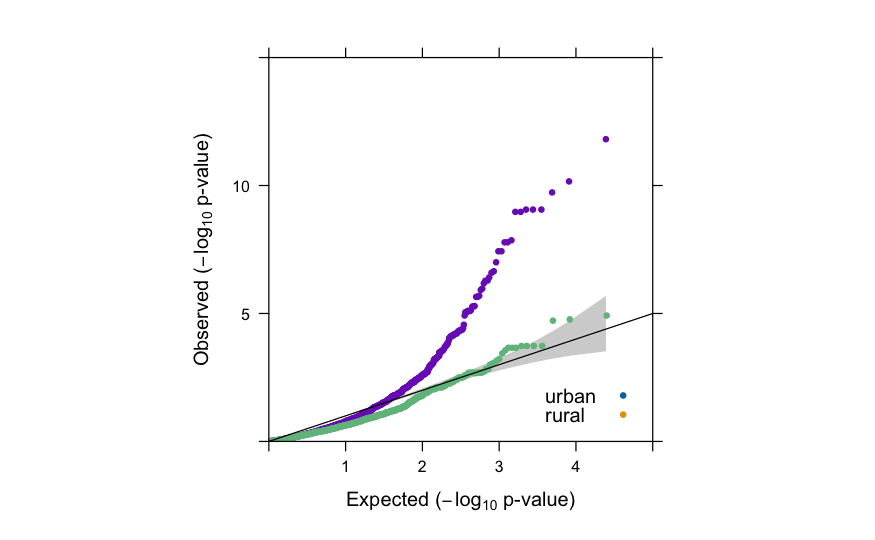

```r
select_v_all <- list("urban" = na.omit(res_uc$padj), "rural" = na.omit(res_rc$padj))
select_v_all_qq <- qqunif.plot(select_v_all, auto.key=list(corner=c(.95,.05)), col=c("#7B2BC1", "#6FBD8B"))
select_v_all_qq
```

How to derive residuals: https://support.bioconductor.org/p/60567/

```r
# Extract the residuals (batch and total.reads corrected counts)
fitted.common.scale = t(t(assays(dds)[["mu"]])/sizeFactors(dds))
residuals <- counts(dds, normalized=T) - fitted.common.scale

# function to filter by significant genes
filter_residuals <- function(residuals, sig_results) {
  filtered_residuals <- residuals[sig_results$ensembl_gene_id, , drop = FALSE]
  return(filtered_residuals)
}

# Use lapply to filter the "residuals" sub-element and retain "sig_results"
residuals_filt_uc <- filter_residuals(residuals, sig_uc) %>%
    as.data.frame() %>%
    rownames_to_column("ensembl_gene_id") %>%
  mutate(model="urban_v_ctrl")

residuals_filt_rc <- filter_residuals(residuals, sig_rc) %>%
    as.data.frame() %>%
    rownames_to_column("ensembl_gene_id") %>%
  mutate(model="rural_v_ctrl")

residuals_melt <- rbind(residuals_filt_rc, residuals_filt_uc) %>%
  pivot_longer(
    cols = -c("model", "ensembl_gene_id"),
    names_to = "SampleID",
    values_to = "residual_gene_count"
  ) %>%
  left_join(meta[,c("SampleID", "urbanism")], by="SampleID") %>%
  filter(!(model=="urban_v_ctrl" & urbanism=="rural")) %>%
  filter(!(model=="rural_v_ctrl" & urbanism=="urban"))
```

```r
library(shiny)

# Assuming you have already loaded your data into 'residuals_melt'

# Define the UI
ui <- fluidPage(
  titlePanel("Batch + urbanism: Significant results only"),
  mainPanel(
    uiOutput("gene_selector_ui"),  # Dynamic gene selector
    plotOutput("boxplot"),
    fluidRow(
      column(4, actionButton("prev_plot", "Previous Plot")),
      column(4, actionButton("next_plot", "Next Plot"))
    )
  )
)

# Define the server
server <- function(input, output, session) {
  # Create a list of unique microbe_gene values
  unique_genes <- unique(residuals_melt$ensembl_gene_id)

  # Initialize a reactive value to keep track of the current index
  current_gene_index <- reactiveVal(1)

  # Create a dynamic UI element for gene selection
  output$gene_selector_ui <- renderUI({
    selectInput("gene_selector", "Select gene:", choices = unique_genes)
  })

  # Create the dotplot
  output$boxplot <- renderPlot({
    ggplot(selected_data(), aes(x = urbanism, y = residual_gene_count, fill = urbanism)) +
      geom_boxplot(alpha = 0.7) +
      geom_jitter(width = 0.2) +
      scale_fill_manual(values = c("grey", "#6FBD8B", "#7B2BC1")) +
      theme_linedraw() +
      facet_wrap(~model, scales = "free")
  })

  # Define an observer for the "Next Plot" button
  observeEvent(input$next_plot, {
    # Increment the index to display the next plot
    current_gene_index(current_gene_index() + 1)

    # Wrap back to the first plot if all plots have been shown
    if (current_gene_index() > length(unique_genes)) {
      current_gene_index(1)
    }

    # Update the selected gene in the dropdown menu
    updateSelectInput(session, "gene_selector", selected = unique_genes[current_gene_index()])
  })

  # Define an observer for the "Previous Plot" button
  observeEvent(input$prev_plot, {
    # Decrement the index to display the previous plot
    current_gene_index(current_gene_index() - 1)

    # Wrap to the last plot if going back from the first plot
    if (current_gene_index() < 1) {
      current_gene_index(length(unique_genes))
    }

    # Update the selected gene in the dropdown menu
    updateSelectInput(session, "gene_selector", selected = unique_genes[current_gene_index()])
  })

  # Create a reactive data subset based on the current index and selected gene
  selected_data <- reactive({
    filter(residuals_melt, ensembl_gene_id == input$gene_selector)
  })
}

# Run the Shiny app
shinyApp(ui, server)
```

[output not shown]

[output cut: 17 more lines]

```
NA
```

Functional analysis First annotate data with gene labels compatible with enrichment analyses. I like to have the uniprot gene symbol (hgnc_symbol) and a description just for my own readability.

```r
library(ensembldb)
library(biomaRt)
ensembl = useEnsembl(biomart="ensembl", dataset="hsapiens_gene_ensembl")

# Define annotations
att_interest <- c("ensembl_gene_id", "description", "hgnc_symbol") #"ensembl_transcript_id",

annotate_ensembl <- function(resdf){biomaRt::getBM(
  attributes = att_interest,
  filters = "ensembl_gene_id",
  values = resdf$ensembl_gene_id,
  mart = ensembl) %>%
  left_join(resdf, by="ensembl_gene_id")
}
```

```r
uni <- unique(res_rc$ensembl_gene_id) %>%
  as.data.frame()
colnames(uni) <- "ensembl_gene_id"
uni <- annotate_ensembl(uni)
```

```
Batch submitting query [============================>---------------------------------------------------------]  33% eta:  9s
Batch submitting query [========================================================>-----------------------------]  67% eta:  3s
```

https://cran.r-project.org/web/packages/msigdbr/vignettes/msigdbr-intro.html https://www.gsea-msigdb.org/gsea/msigdb/human/genesets.jsp?collection=CP

Next choose the databases you want to test. KEGG and Reactome are the most relevant for my research. Per Sambhawa’s 2022 pub, I am only investigating a pathway if it contains at least 25 genes but less than 300 genes.

```r
library(msigdbr)
msigdb_cpPID = msigdbr(species = "human", category = "C2", subcategory = "CP:PID")
msigdb_cpKEGG = msigdbr(species = "human", category = "C2", subcategory = "CP:KEGG")
msigdb_cpREACTOME = msigdbr(species = "human", category = "C2", subcategory = "CP:REACTOME")
msigdb_cpBIOCARTA = msigdbr(species = "human", category = "C2", subcategory = "CP:BIOCARTA")

msigdb_cp <- rbind(msigdb_cpKEGG, msigdb_cpREACTOME) %>%
  rbind(msigdb_cpPID)

msigdb_cp_summary <- msigdb_cp %>%
  group_by(gs_name) %>%
  summarize(GeneCount = n_distinct(gene_symbol)) %>%
  # sambhawas filtering cutoffs
  dplyr::filter(GeneCount >25, GeneCount < 300)

msigdb_cp_filt <- msigdb_cp %>%
  dplyr::filter(gs_name %in% msigdb_cp_summary$gs_name)
msigdb_cpPID_filt <- msigdb_cpPID %>%
  dplyr::filter(gs_name %in% msigdb_cp_summary$gs_name)
msigdb_cpKEGG_filt <- msigdb_cpKEGG %>%
  dplyr::filter(gs_name %in% msigdb_cp_summary$gs_name)
msigdb_cpREACTOME_filt <- msigdb_cpREACTOME %>%
  dplyr::filter(gs_name %in% msigdb_cp_summary$gs_name)
msigdb_cpBIOCARTA_filt <- msigdb_cpBIOCARTA %>%
  dplyr::filter(gs_name %in% msigdb_cp_summary$gs_name)
```

clusterProfiler for enrichment analysis. Once again I am trying 3 different GSEAs: “shared”, “uc” and “rc”

```r
library(clusterProfiler)

msigdb_cp_t2g = msigdb_cp_filt %>% dplyr::distinct(gs_name, gene_symbol) %>% as.data.frame()

shared_enrich <- enricher(gene = unique(sig_top$hgnc_symbol), TERM2GENE = msigdb_cp_t2g, universe = uni$hgnc_symbol)
shared_enrich_res <- shared_enrich@result %>%
  dplyr::filter(Count > 3, p.adjust < 0.1)

uc_enrich <- enricher(gene = unique(uc_top$hgnc_symbol), TERM2GENE = msigdb_cp_t2g, universe = uni$hgnc_symbol)
uc_enrich_res <- uc_enrich@result %>%
  dplyr::filter(Count > 3, p.adjust < 0.1) %>%
  mutate(model="uc")

rc_enrich <- enricher(gene = unique(rc_top$hgnc_symbol), TERM2GENE = msigdb_cp_t2g, universe = uni$hgnc_symbol)
rc_enrich_res <- rc_enrich@result %>%
  dplyr::filter(Count > 3, p.adjust < 0.1) %>%
  mutate(model="rc")
```

Plot the results. Here I combined the results from my different enrichment tests “uc” and “rc”

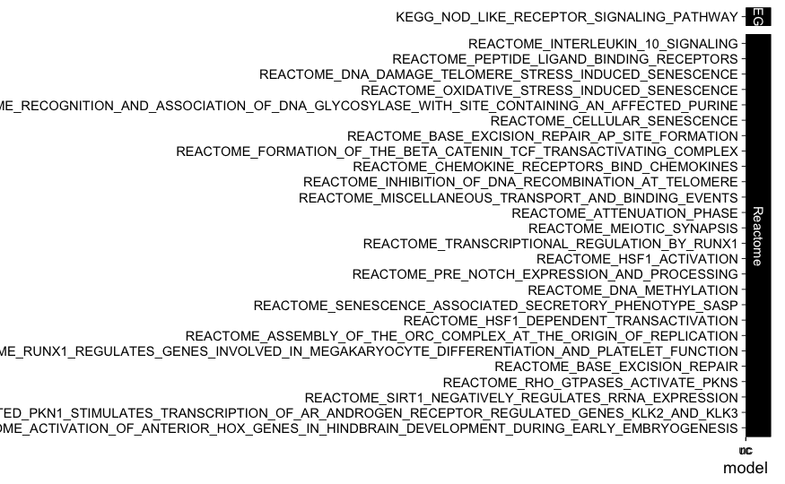

```r
enriched_pathways <- rbind(uc_enrich_res, rc_enrich_res) %>%
  mutate(db = case_when(
    grepl("REACTOME", ID) ~ "Reactome",
    grepl("KEGG", ID) ~ "KEGG",
    grepl("PID", ID) ~ "PID",
    TRUE ~ "Other"  # Add a default value for other cases
  )) %>%
  mutate(neglog10_p.adjust = -log10(p.adjust)) %>%
  mutate(as.numeric(neglog10_p.adjust)) %>%
  arrange(neglog10_p.adjust)
enriched_pathways$ID <- factor(enriched_pathways$ID, levels=unique(enriched_pathways$ID))

ggplot(enriched_pathways, aes(x=model, y=ID, color=model, size=neglog10_p.adjust)) +
  geom_point() +
  scale_color_manual(values = c("#6FBD8B", "#7B2BC1")) +
  facet_grid(db ~ ., scales="free", space="free") +
  theme_linedraw()
ggsave("results/figs/RNAseq-urbanism/enriched_pathways.png", width=11, height=6.5)
```

Now plotting just the results of the “shared” model

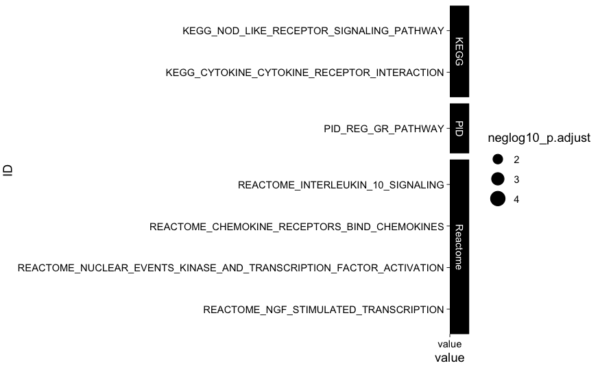

```r
enriched_pathways_sharedgenesonly <- shared_enrich_res %>%
  mutate(db = case_when(
    grepl("REACTOME", ID) ~ "Reactome",
    grepl("KEGG", ID) ~ "KEGG",
    grepl("PID", ID) ~ "PID",
    TRUE ~ "Other"  # Add a default value for other cases
  )) %>%
  mutate(neglog10_p.adjust = -log10(p.adjust)) %>%
  mutate(as.numeric(neglog10_p.adjust)) %>%
  arrange(neglog10_p.adjust) %>%
  mutate(value="value")
enriched_pathways_sharedgenesonly$ID <- factor(enriched_pathways_sharedgenesonly$ID, levels=unique(enriched_pathways_sharedgenesonly$ID))

ggplot(enriched_pathways_sharedgenesonly, aes(x=value, y=ID, size=neglog10_p.adjust)) +
  geom_point() +
  #scale_color_manual(values = c("#6FBD8B", "#7B2BC1")) +
  facet_grid(db ~ ., scales="free", space="free") +
  theme_linedraw()
ggsave("results/figs/RNAseq-urbanism/enriched_pathways_sharedgenesonly.png", width=8, height=2)
```

```r
rm(list = ls())
```